CS F364: Design & Analysis of Algorithms

# Design and Analysis of Algorithms

Lecture 24 25 |2026-05-21

Dr. Tulasimohan Molli BITS Pilani, Hyderabad Campus

# Network Flow

- Network Flow

## Network Flow

- The definition of the network flow problem.
- Maximum Flow and Minimum Cut
- The Ford-Fulkerson algorithm
- The maxflow-mincut theorem
- The bipartite matching problem.

## Flows and Cuts

Let $f$ be any flow and let $(A, B)$ be any $s-t$ cut. Then, the net flow sent across the cut is equal to the amount leaving $s$.

$\sum_{e\mbox{ out of }A}f(e) - \sum_{e\mbox{ in to }A}f(e) = |f|$

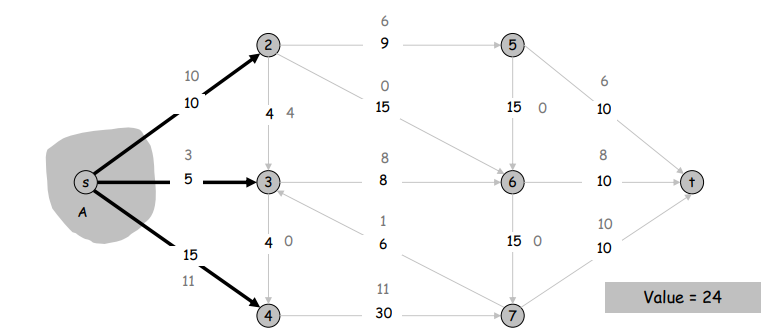

## Flows and Cuts

Let $f$ be any flow and let $(A, B)$ be any $s-t$ cut. Then, the net flow sent across the cut is equal to the amount leaving $s$.

$\sum_{e\mbox{ out of }A}f(e) - \sum_{e\mbox{ in to }A}f(e) = |f|$

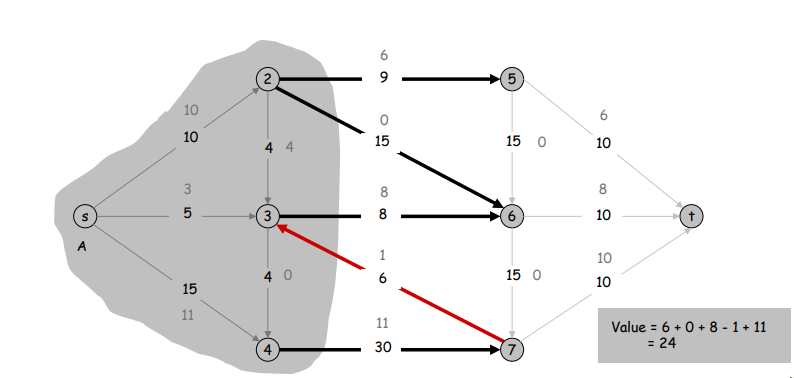

## Flows and Cuts

Let $f$ be any flow and let $(A, B)$ be any $s-t$ cut. Then, the net flow sent across the cut is equal to the amount leaving $s$.

$\sum_{e\mbox{ out of }A}f(e) - \sum_{e\mbox{ in to }A}f(e) = |f|$

*Proof*. *Proof.*
$$\begin{aligned}
|f| &= \displaystyle\sum_{e\mbox{ out of }s}f(e)
= \displaystyle\sum_{v\in A}(\displaystyle\sum_{e\mbox{ out of }v}f(e)-\displaystyle\sum_{e\mbox{ in to }v}f(e))\\
&= \displaystyle\sum_{e\mbox{ out of A }}f(e) - \displaystyle\sum_{e\mbox{ in to }A}f(e).
\end{aligned}$$
◻

## Flows and Cuts

**Weak duality:** Let $f$ be any flow, and let $(A, B)$ be any $s-t$ cut. Then the value of the flow is at most the capacity of the cut.

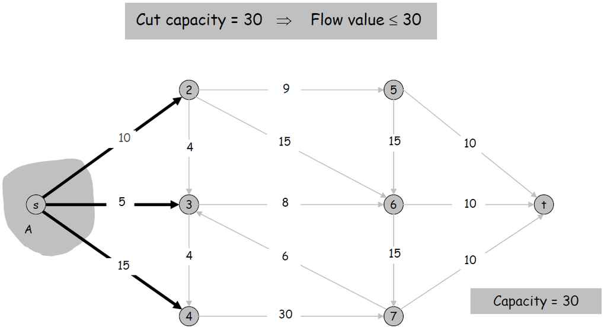

## Flows and Cuts

Let $f$ be any flow, and let $(A, B)$ be any $s-t$ cut. Then $|f|\leq cap(A, B)$.

*Proof*.

## Optimality

Let $f$ be any flow and $(A, B)$ be any cut. If $|f| = cap(A, B)$, then $f$ is a max flow and $(A, B)$ is a min cut.

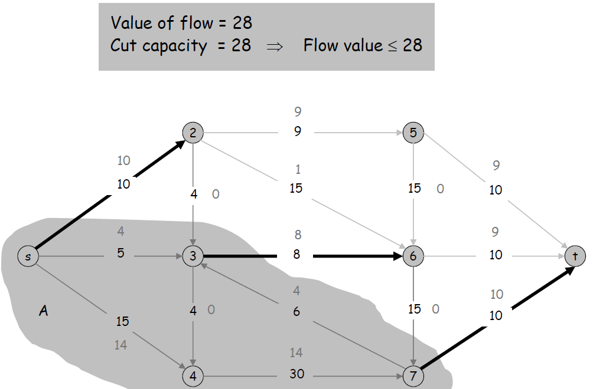

## Max Flow Algorithm

Greedy Algorithm:

- Start with $f(e)=0$ for all edge $e\in E$.
- Find an $s-t$ path $P$ where each edge has $f(e) < c(e)$.
- Augment the flow along path $P$.
- Repeat until you get stuck.

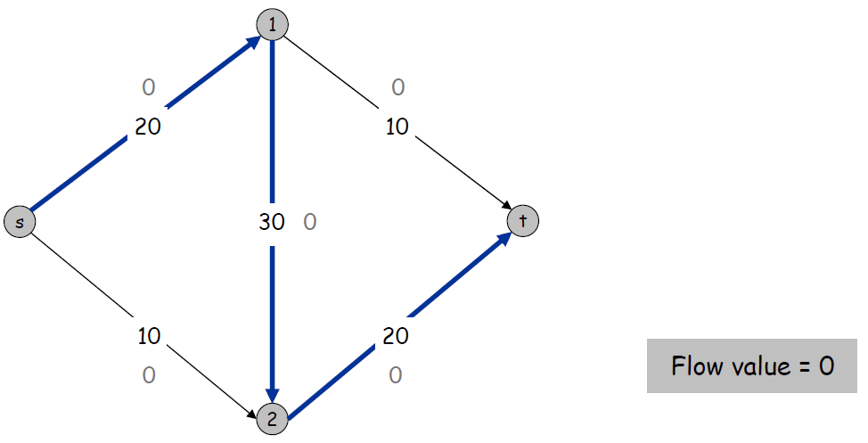